# Utiliser R et le package `MSstatsPTM` après une recherche MaxQuant pour l’analyse de PTM

Ecole thématique CNRS 2026 - Sète

# 1. But de ce tutoriel

Dans des études de modifications post-traductionnelles (e.g., phosphorylation), un peptide modifié peut varier en abundance entre des conditions biologiques, sans que cette variation d’abondance ne soit liée à sa modification. En effet, elle peut simplement être liée à la variation d’abondance de sa protéine d’appartenance. Il faut donc vérifier que la dynamique du peptide modifié soit différente de celle de sa protéine d’appartenance entre les conditions étudiées.

MSstatsPTM adresse ce problème en produisant trois modèles:

- **PTM.Model**: analyse différentielle du peptide modifié (“unadjusted”)
- **PROTEIN.Model**: analyse différentielle de la protéine d’appartenance (“unmodified proteome”)
- **ADJUSTED.Model**: variations de PTM ajustées par rapport aux variations de la protéine (“*PTM change* - *protein change*”)

Nous allons utiliser un dataset public disponible sur PRIDE (**PXD020019**). C’est une analyse protéomique de cellules infectées par le SARS-COV-2 basée sur le logiciel MaxQuant. Il contient des échantillons enrichis en phosphorylation, d’autres en ubiquitination, et des échantillons non-enrichis.

# 2. Installation et chargement des packages R nécessaires

On installe les packages nécessaires si besoin. Ce n’est à exécuter qu’une seule fois par machine.

Voici ce que fait chaque package:

- BiocManager : permet d’installer les packages dispo sur Bioconductor (packages uniquement bioinformatiques). Il est conseillé d’installer la dernière version disponible.
- MSstats : permet d’effectuer des analyses différentielles “classiques”
- MSstatsPTM : extension de MSstats pour l’analyse de PTMs
- data.table : lecture rapide de gros jeux de données (fread)
- stringi : permet de faire de la manipulation de chaines de caractères

```r
if (!require("BiocManager", quietly = TRUE))
    install.packages("BiocManager")

BiocManager::install("MSstats")
BiocManager::install("MSstatsPTM")
install.packages("data.table")
install.packages("stringi")
```

```r
library(MSstatsPTM)
library(MSstats)
library(data.table)
library(stringi)
```

# 3. Téléchargement et inspection du fichier “evidence” de MaxQuant:

MaxQuant fournit un fichier appelé “evidence.txt” qui contient une ligne par peptide identifié dans un échantillon. Ce fichier peut être volumineux. Son import dans la session R peut prendre du temps.

```r
# L'import du fichier evidence peut prendre un certain temps
evidence <- fread("https://ftp.pride.ebi.ac.uk/pride/data/archive/2020/07/PXD020019/evidence.txt")

# Les colonnes du fichier contiennent parfois des espaces
# Il faut les convertirs en "." pour faciliter l'utilisation de MSstats.
# gsub() remplace tous les espaces par des points dans les noms de colonne.
setnames(evidence, gsub(" ", ".", names(evidence), fixed = TRUE))

# On peut vérifier les 5 premières lignes du fichier importé pour être sûr qu'on
# a bien importé les données. Ici, on n'affiche que les colonnes "Raw file", "Experiment"
# et "Fraction"
evidence[1:5, .(Raw.file, Experiment, Fraction)]
```

```
##                               Raw.file      Experiment Fraction
##                                 <char>          <char>    <int>
## 1: 20200421_QX7_OzKa_SA_COV2_FPMS_ME_3       mock_6h_3        1
## 2: 20200421_QX7_OzKa_SA_COV2_FPMS_ML_2      mock_24h_2        1
## 3: 20200421_QX7_OzKa_SA_COV2_FPMS_ML_3      mock_24h_3        1
## 4: 20200421_QX7_OzKa_SA_COV2_FPMS_TE_2  SARS_COV2_6h_2        1
## 5: 20200421_QX7_OzKa_SA_COV2_FPMS_TL_2 SARS_COV2_24h_2        1
```

```r
#On affiche que les valeurs "Fraction" (utile pour comprendre le design de l'xp)
unique(evidence$Fraction)
```

```
## [1]  1 21 11
```

# 4. Préparation des inputs pour l’analyse

## 4.1. Identifier les runs liés au protéome “global” et ceux enrichis en PTM.

Dans ce dataset,dans la colonne `Experiment`, on a:

- Global proteome runs: `mock_6h_1`, `SARS_COV2_24h_4`, …
- Phospho-enriched runs: `Phospho_mock_6h_1`, …
- Ubi-enriched runs: `Ubi_mock_6h_1`, …

Cette commande compte le nombre de lignes par “Experiment”. [order(-N)] permet de les afficher par ordre décroissant.

```r
evidence[, .N, by = Experiment][order(-N)][1:30]
```

```
##              Experiment     N
##                  <char> <int>
##  1:          mock_24h_1 52294
##  2:           mock_6h_1 51838
##  3:      SARS_COV2_6h_1 51554
##  4:      SARS_COV2_6h_2 51492
##  5:          mock_24h_2 51392
##  6:           mock_6h_3 51042
##  7:           mock_6h_2 50668
##  8:     SARS_COV2_24h_2 50171
##  9:          mock_24h_3 49737
## 10:     SARS_COV2_24h_3 49646
## 11:      SARS_COV2_6h_3 48550
## 12:     SARS_COV2_24h_1 47379
## 13:          mock_24h_4 43059
```

[output cut: 18 more lines]

## 4.2. Séparer le fichier “evidence” en un fichier lié aux enrichissements, et un lié aux protéines

Le fichier “evidence” contient des runs de différentes expériences (global, phospho enrichment, ubi enrichment).  
Pour pouvoir utiliser correctement les fonctions de *MSstatsPTM*, il faut créer des datasets différents:

- `evidence_ptm`: seulement les échantillons enrichis en phosphorylation
- `evidence_prot`: seulement les échantillons de protéomique global (sans enrichissement)

La fonction grepl() retourne “TRUE” ou “FALSE” pour chaque ligne si le pattern recherché est trouvé.

```r
is_phospho <- grepl("^Phospho_", evidence$Experiment)
is_ubi     <- grepl("^Ubi_", evidence$Experiment)
is_global  <- !is_phospho & !is_ubi

evidence_ptm  <- evidence[is_phospho]
evidence_prot <- evidence[is_global]

# On vérifie que tout est ok en listant les "experiment" uniques dans chaque jeu
# de données
evidence_ptm[, unique(Experiment)]
```

```
##  [1] "Phospho_mock_6h_2"       "Phospho_mock_6h_3"
##  [3] "Phospho_mock_24h_1"      "Phospho_mock_24h_2"
##  [5] "Phospho_mock_24h_3"      "Phospho_SARS_COV2_6h_1"
##  [7] "Phospho_SARS_COV2_6h_2"  "Phospho_SARS_COV2_6h_3"
##  [9] "Phospho_SARS_COV2_24h_1" "Phospho_SARS_COV2_24h_2"
## [11] "Phospho_SARS_COV2_24h_3" "Phospho_mock_6h_1"
```

```r
evidence_prot[, unique(Experiment)]
```

```
##  [1] "mock_6h_3"       "mock_24h_2"      "mock_24h_3"      "SARS_COV2_6h_2"
##  [5] "SARS_COV2_24h_2" "SARS_COV2_24h_3" "SARS_COV2_6h_3"  "mock_6h_4"
##  [9] "mock_24h_4"      "SARS_COV2_6h_4"  "SARS_COV2_24h_4" "mock_6h_1"
## [13] "mock_6h_2"       "mock_24h_1"      "SARS_COV2_6h_1"  "SARS_COV2_24h_1"
```

## 4.3 Construire la table d’annotation

MSstats/MSstatsPTM ont besoin d’une table `annotation` qui indique, pour chaque run :

- `Run` : nom du run (ici la colonne `Raw.file` de MaxQuant)
- `Condition` : condition biologique (mock ou SARS_COV2)
- `BioReplicate` : numéro de réplicat

Dans ce dataset, ces informations sont codées dans la colonne `Experiment` (ex. `Phospho_mock_6h_2`).

### 4.3.1 Créer une table “Run <-> Experiment” (une ligne par run)

Parce qu’un même run apparaît plusieurs fois dans `evidence.txt` (une ligne par peptide/feature), on utilise `unique(..., by="Run")`.  
L’annotation doit contenir **une seule ligne par run**.

```r
# Exemple pour les runs PTM (phospho) :
annot_ptm_dt <- unique(evidence_ptm[, .(Run = Raw.file, Experiment)], by = "Run")

# Exemple pour les runs global proteome :
annot_prot_dt <- unique(evidence_prot[, .(Run = Raw.file, Experiment)], by = "Run")

head(annot_ptm_dt)
```

```
##                                        Run             Experiment
##                                     <char>                 <char>
## 1: 20200425_QX8_OzKa_SA_COV2_EasyPhos_ME_2      Phospho_mock_6h_2
## 2: 20200425_QX8_OzKa_SA_COV2_EasyPhos_ME_3      Phospho_mock_6h_3
## 3: 20200425_QX8_OzKa_SA_COV2_EasyPhos_ML_1     Phospho_mock_24h_1
## 4: 20200425_QX8_OzKa_SA_COV2_EasyPhos_ML_2     Phospho_mock_24h_2
## 5: 20200425_QX8_OzKa_SA_COV2_EasyPhos_ML_3     Phospho_mock_24h_3
## 6: 20200425_QX8_OzKa_SA_COV2_EasyPhos_TE_1 Phospho_SARS_COV2_6h_1
```

```r
head(annot_prot_dt)
```

```
##                                    Run      Experiment
##                                 <char>          <char>
## 1: 20200421_QX7_OzKa_SA_COV2_FPMS_ME_3       mock_6h_3
## 2: 20200421_QX7_OzKa_SA_COV2_FPMS_ML_2      mock_24h_2
## 3: 20200421_QX7_OzKa_SA_COV2_FPMS_ML_3      mock_24h_3
## 4: 20200421_QX7_OzKa_SA_COV2_FPMS_TE_2  SARS_COV2_6h_2
## 5: 20200421_QX7_OzKa_SA_COV2_FPMS_TL_2 SARS_COV2_24h_2
## 6: 20200421_QX7_OzKa_SA_COV2_FPMS_TL_3 SARS_COV2_24h_3
```

### 4.3.2 Extraire Condition / Time / BioReplicate depuis `Experiment`

On utilise une expression régulière (regex) qui décrit la structure des noms :

- préfixe optionnel : `Phospho_` ou `Ubi_`
- condition : `mock` ou `SARS_COV2`
- temps : `6h` ou `24h`
- replicate : un chiffre

La syntaxe regex peut apparaître complexe, mais vous avez seulement besoin de comprendre ce que chaque colonne contiendra après cette étape.

```r
pat <- "^(?:(Ubi|Phospho)_)?(mock|SARS_COV2)_(6h|24h)_([0-9]+)$"
```

Puis on applique ce regex et on remplit les colonnes :

```r
# Application aux annotations PTM
m <- stringi::stri_match_first_regex(annot_ptm_dt$Experiment, pat)

#fifelse est une version rapide de ifelse (package data.table)
# si m[,2] est manquant (NA), alors c'est un échantillon de protéomique globale ("Global")
annot_ptm_dt[, Enrichment := fifelse(is.na(m[,2]), "Global", m[,2])]
annot_ptm_dt[, Condition  := m[,3]]  #"mock" ou "SARS_COV2"
annot_ptm_dt[, Time       := m[,4]]  # "6h" ou "24h"
annot_ptm_dt[, BioReplicate := as.integer(m[,5])] #numéro de réplicat

# Vérification rapide : est-ce que tout a été bien extrait ?
head(annot_ptm_dt)
```

```
##                                        Run             Experiment Enrichment
##                                     <char>                 <char>     <char>
## 1: 20200425_QX8_OzKa_SA_COV2_EasyPhos_ME_2      Phospho_mock_6h_2    Phospho
## 2: 20200425_QX8_OzKa_SA_COV2_EasyPhos_ME_3      Phospho_mock_6h_3    Phospho
## 3: 20200425_QX8_OzKa_SA_COV2_EasyPhos_ML_1     Phospho_mock_24h_1    Phospho
## 4: 20200425_QX8_OzKa_SA_COV2_EasyPhos_ML_2     Phospho_mock_24h_2    Phospho
## 5: 20200425_QX8_OzKa_SA_COV2_EasyPhos_ML_3     Phospho_mock_24h_3    Phospho
## 6: 20200425_QX8_OzKa_SA_COV2_EasyPhos_TE_1 Phospho_SARS_COV2_6h_1    Phospho
##    Condition   Time BioReplicate
##       <char> <char>        <int>
## 1:      mock     6h            2
## 2:      mock     6h            3
## 3:      mock    24h            1
## 4:      mock    24h            2
## 5:      mock    24h            3
## 6: SARS_COV2     6h            1
```

Même chose pour le global proteome :

```r
# Application aux annotations PROTEIN (global)
m <- stringi::stri_match_first_regex(annot_prot_dt$Experiment, pat)

annot_prot_dt[, Enrichment := fifelse(is.na(m[,2]), "Global", m[,2])]
annot_prot_dt[, Condition  := m[,3]]
annot_prot_dt[, Time       := m[,4]]
annot_prot_dt[, BioReplicate := as.integer(m[,5])]

head(annot_prot_dt)
```

```
##                                    Run      Experiment Enrichment Condition
##                                 <char>          <char>     <char>    <char>
## 1: 20200421_QX7_OzKa_SA_COV2_FPMS_ME_3       mock_6h_3     Global      mock
## 2: 20200421_QX7_OzKa_SA_COV2_FPMS_ML_2      mock_24h_2     Global      mock
## 3: 20200421_QX7_OzKa_SA_COV2_FPMS_ML_3      mock_24h_3     Global      mock
## 4: 20200421_QX7_OzKa_SA_COV2_FPMS_TE_2  SARS_COV2_6h_2     Global SARS_COV2
## 5: 20200421_QX7_OzKa_SA_COV2_FPMS_TL_2 SARS_COV2_24h_2     Global SARS_COV2
## 6: 20200421_QX7_OzKa_SA_COV2_FPMS_TL_3 SARS_COV2_24h_3     Global SARS_COV2
##      Time BioReplicate
##    <char>        <int>
## 1:     6h            3
## 2:    24h            2
## 3:    24h            3
## 4:     6h            2
## 5:    24h            2
## 6:    24h            3
```

### 4.3.3 Garder uniquement les colonnes nécessaires

Les converters de MSstats/MSstatsPTM utilisent surtout : `Run`, `Condition`, `BioReplicate`.

```r
annot_ptm  <- as.data.frame(annot_ptm_dt[, .(Run, Condition, BioReplicate)])
annot_prot <- as.data.frame(annot_prot_dt[, .(Run, Condition, BioReplicate)])

head(annot_ptm)
```

```
##                                       Run Condition BioReplicate
## 1 20200425_QX8_OzKa_SA_COV2_EasyPhos_ME_2      mock            2
## 2 20200425_QX8_OzKa_SA_COV2_EasyPhos_ME_3      mock            3
## 3 20200425_QX8_OzKa_SA_COV2_EasyPhos_ML_1      mock            1
## 4 20200425_QX8_OzKa_SA_COV2_EasyPhos_ML_2      mock            2
## 5 20200425_QX8_OzKa_SA_COV2_EasyPhos_ML_3      mock            3
## 6 20200425_QX8_OzKa_SA_COV2_EasyPhos_TE_1 SARS_COV2            1
```

```r
head(annot_prot)
```

```
##                                   Run Condition BioReplicate
## 1 20200421_QX7_OzKa_SA_COV2_FPMS_ME_3      mock            3
## 2 20200421_QX7_OzKa_SA_COV2_FPMS_ML_2      mock            2
## 3 20200421_QX7_OzKa_SA_COV2_FPMS_ML_3      mock            3
## 4 20200421_QX7_OzKa_SA_COV2_FPMS_TE_2 SARS_COV2            2
## 5 20200421_QX7_OzKa_SA_COV2_FPMS_TL_2 SARS_COV2            2
## 6 20200421_QX7_OzKa_SA_COV2_FPMS_TL_3 SARS_COV2            3
```

```r
# Combien de runs ?
nrow(annot_ptm)
```

```
## [1] 12
```

```r
nrow(annot_prot)
```

```
## [1] 16
```

## 4.4. Préparer le fichier FASTA (Human + SARS-CoV-2)

Certaines sorties de MaxQuant ne fournissent pas directement la position du site de PTM dans la *protéine*.  
`MSstatsPTM` peut utiliser un fichier FASTA pour associer les peptides modifiés à leurs positions de site dans la séquence protéique.

Pour cela, nous téléchargeons et fusionnons deux fichiers FASTA (humain et sars-cov-2), puis nous les enregistrons localement.

```r
fasta_human_url <- "https://ftp.pride.ebi.ac.uk/pride/data/archive/2020/07/PXD020019/uniprot-9606_proteome_human_reviewed_canonical_isoforms_191008.fasta"
fasta_sars_url  <- "https://ftp.pride.ebi.ac.uk/pride/data/archive/2020/07/PXD020019/20200531_fasta_sars-cov-2.fasta"

fasta_human <- fread(fasta_human_url, header = FALSE)
fasta_sars  <- fread(fasta_sars_url,  header = FALSE)

fasta_all <- rbind(fasta_human, fasta_sars)

# tempdir() retourne un fichier temporaire
# On sauve le fichier FASTA fusionné dans ce fichier temporaire
fasta_path <- file.path(tempdir(), "proteins_human_plus_sarscov2.fasta")
writeLines(fasta_all$V1, con = fasta_path)

# Affiche la première ligne du fichier FASTA
fasta_all$V1[1]
```

```
## [1] ">sp|Q9HBI6|CP4FB_HUMAN Cytochrome P450 4F11 OS=Homo sapiens OX=9606 GN=CYP4F11 PE=1 SV=3"
```

```r
# Affiche le chemin vers le fichier FASTA
fasta_path
```

```
## [1] "C:\\Users\\qgiaigia\\AppData\\Local\\Temp\\Rtmp2JAUiw/proteins_human_plus_sarscov2.fasta"
```

# 5. Convertir le fichier “evidence” de MaxQuant en un input “MSstatsPTM”

## 5.1. Runs enrichis en phosphorylation

MaxQtoMSstatsPTMFormat() lit le fichier “evidence” de MaxQuant et le reformatte en la structure que MSstatsPTM attends pour une analyse au niveau PTM.

Paramètres clés :

- `mod_id` : motif (pattern regex) permettant d’identifier les modifications de phosphorylation dans les chaînes de caractères de MaxQuant.
- `use_unmod_peptides = FALSE` : puisqu’il s’agit d’un fichier *evidence* issu d’un enrichissement en phosphopeptides, nous ne voulons donc pas inférer ici l’abondance globale des protéines.
- `labeling_type` : “LF” = Label-Free quantification.
- `fasta_protein_name` : permet l’extraction du code Uniprot à partir du fasta

Cette fonction peut prendre du temps.

```r
ms_ptm <- MaxQtoMSstatsPTMFormat(
  evidence = evidence_ptm,
  annotation = annot_ptm[, c("Run", "Condition", "BioReplicate")],
  fasta = fasta_path,
  fasta_protein_name = "uniprot_ac",  #FASTA headers du type >sp|Q9HBI6|... (accession = Q9HBI6)
  mod_id = "\\(Phospho \\(STY\\)\\)",
  use_unmod_peptides = FALSE,
  labeling_type = "LF",
  which_proteinid_ptm = "Proteins"
)
```

[output not shown]

```r
# What did we get?
names(ms_ptm)
```

```
## [1] "PTM"
```

```r
head(ms_ptm$PTM)
```

```
##   ProteinName                     PeptideSequence PrecursorCharge FragmentIon
## 1 Q6SPF0_S161 AAAAAATAPPS(Phospho (STY))PGPAQPGPR               2          NA
## 2 Q6SPF0_S161 AAAAAATAPPS(Phospho (STY))PGPAQPGPR               2          NA
## 3 Q6SPF0_S161 AAAAAATAPPS(Phospho (STY))PGPAQPGPR               2          NA
## 4 Q6SPF0_S161 AAAAAATAPPS(Phospho (STY))PGPAQPGPR               2          NA
## 5 Q6SPF0_S161 AAAAAATAPPS(Phospho (STY))PGPAQPGPR               2          NA
## 6 Q6SPF0_S161 AAAAAATAPPS(Phospho (STY))PGPAQPGPR               2          NA
##   ProductCharge IsotopeLabelType Condition BioReplicate
## 1            NA                L      mock            1
## 2            NA                L      mock            2
## 3            NA                L      mock            3
## 4            NA                L      mock            1
## 5            NA                L      mock            2
## 6            NA                L      mock            3
##                                       Run Fraction Intensity
## 1 20200425_QX8_OzKa_SA_COV2_EasyPhos_ME_1        1  10293000
## 2 20200425_QX8_OzKa_SA_COV2_EasyPhos_ME_2        1  18294000
## 3 20200425_QX8_OzKa_SA_COV2_EasyPhos_ME_3        1  15982000
## 4 20200425_QX8_OzKa_SA_COV2_EasyPhos_ML_1        1   6912800
## 5 20200425_QX8_OzKa_SA_COV2_EasyPhos_ML_2        1  13164000
## 6 20200425_QX8_OzKa_SA_COV2_EasyPhos_ML_3        1  12560000
```

## 5.2. Runs de la protéomique “globale” (“unmodified proteome”)

Pour le protéome global, nous allons utiliser le package R `MSstats` et les fichiers:

- `evidence.txt`
- `proteinGroups.txt`

On télécharge `proteinGroups.txt` depuis PRIDE, on créé ensuite le fichier evidence “global”, le fichier “annotation” correspondant puis on le convertit au format MSstats.

```r
# Téléchargement de proteinGroups.txt (requis pour le converter de MaxQuant à MSstats)
pg_url <- "https://ftp.pride.ebi.ac.uk/pride/data/archive/2020/07/PXD020019/proteinGroups.txt"
pg_file <- file.path(tempdir(), "proteinGroups.txt")
download.file(pg_url, destfile = pg_file, mode = "wb")
file.info(pg_file)$size
```

```
## [1] 33029785
```

```r
# Ecris le fichier "evidence" global dans un fichier temporaire
prot_evi_file <- file.path(tempdir(), "evidence_global.txt")
fwrite(evidence_prot, prot_evi_file, sep = "\t", quote = FALSE, na = "NA")

# Fichier annotation pour MSstats (ça peut être un chemin vers le fichier)
prot_annot_file <- file.path(tempdir(), "annotation_global.csv")
fwrite(as.data.table(annot_prot[, c("Run", "Condition", "BioReplicate")]), prot_annot_file)

# Converti le fichier evidence du proteome global au format MSstats
# useUniquePeptide = TRUE : on ne garde que les peptides qui "mappent" sur une
# seule protéine (pas de peptides partagés).
ms_prot <- MSstats::MaxQtoMSstatsFormat(
  evidence = prot_evi_file,
  annotation = prot_annot_file,
  proteinGroups = pg_file,
  useUniquePeptide = TRUE
)
```

[output not shown]

```r
#On vérifie le fichier créé
head(ms_prot)
```

```
##                                         ProteinName
## 1 Q86U42-2;Q86U42;Q92843-2;A6NDY0-2;A6NDY0;A6NDY0-4
## 2 Q86U42-2;Q86U42;Q92843-2;A6NDY0-2;A6NDY0;A6NDY0-4
## 3 Q86U42-2;Q86U42;Q92843-2;A6NDY0-2;A6NDY0;A6NDY0-4
## 4 Q86U42-2;Q86U42;Q92843-2;A6NDY0-2;A6NDY0;A6NDY0-4
## 5 Q86U42-2;Q86U42;Q92843-2;A6NDY0-2;A6NDY0;A6NDY0-4
## 6 Q86U42-2;Q86U42;Q92843-2;A6NDY0-2;A6NDY0;A6NDY0-4
##                             PeptideSequence PrecursorCharge FragmentIon
## 1 (Acetyl (Protein N-term))AAAAAAAAAAGAAGGR               2          NA
## 2 (Acetyl (Protein N-term))AAAAAAAAAAGAAGGR               2          NA
## 3 (Acetyl (Protein N-term))AAAAAAAAAAGAAGGR               2          NA
## 4 (Acetyl (Protein N-term))AAAAAAAAAAGAAGGR               2          NA
## 5 (Acetyl (Protein N-term))AAAAAAAAAAGAAGGR               2          NA
## 6 (Acetyl (Protein N-term))AAAAAAAAAAGAAGGR               2          NA
##   ProductCharge IsotopeLabelType Condition BioReplicate
## 1            NA                L      mock            1
## 2            NA                L      mock            2
## 3            NA                L      mock            3
## 4            NA                L      mock            4
## 5            NA                L      mock            1
## 6            NA                L      mock            2
##                                                Run Fraction Intensity
## 1              20200421_QX7_OzKa_SA_COV2_FPMS_ME_1        1        NA
## 2              20200421_QX7_OzKa_SA_COV2_FPMS_ME_2        1        NA
## 3              20200421_QX7_OzKa_SA_COV2_FPMS_ME_3        1        NA
## 4 20200421_QX7_OzKa_SA_COV2_FPMS_ME_4_200424191210        1  15484000
## 5              20200421_QX7_OzKa_SA_COV2_FPMS_ML_1        1        NA
## 6              20200421_QX7_OzKa_SA_COV2_FPMS_ML_2        1        NA
```

# 6. Construire un objet MSstatsPTM

`MSstatsPTM` nécessite une liste de 2 éléments:

- `PTM`: table au niveau “PTM”
- `PROTEIN`: table au niveau “protéine” (global proteome)

Les deux fichiers sont séparés car ils viennent de différents échantillons (enrichis et non-enrichis). MSstatsPTM les alignera par protéine ID.

```r
raw.input <- list(
  PTM = ms_ptm$PTM,
  PROTEIN = ms_prot
)

#Affichage des premières lignes des deux fichiers
lapply(raw.input, head)
```

```
## $PTM
##   ProteinName                     PeptideSequence PrecursorCharge FragmentIon
## 1 Q6SPF0_S161 AAAAAATAPPS(Phospho (STY))PGPAQPGPR               2          NA
## 2 Q6SPF0_S161 AAAAAATAPPS(Phospho (STY))PGPAQPGPR               2          NA
## 3 Q6SPF0_S161 AAAAAATAPPS(Phospho (STY))PGPAQPGPR               2          NA
## 4 Q6SPF0_S161 AAAAAATAPPS(Phospho (STY))PGPAQPGPR               2          NA
## 5 Q6SPF0_S161 AAAAAATAPPS(Phospho (STY))PGPAQPGPR               2          NA
## 6 Q6SPF0_S161 AAAAAATAPPS(Phospho (STY))PGPAQPGPR               2          NA
##   ProductCharge IsotopeLabelType Condition BioReplicate
## 1            NA                L      mock            1
## 2            NA                L      mock            2
## 3            NA                L      mock            3
## 4            NA                L      mock            1
## 5            NA                L      mock            2
## 6            NA                L      mock            3
```

[output cut: 37 more lines]

# 7. “Summarization” avec `dataSummarizationPTM`

Les données contiennent des mesures multiples par protéine et par échantillon (états de charge, etc.)

Cette étape :

- résume les signaux de PTM au niveau site de modification/peptide pour chaque run
- résume l’abondance globale des protéines pour chaque run
- gère les valeurs manquantes et la normalisation selon les paramètres par défaut (configurables)

C’est l’étape qui prend le plus de temps (suivant la taille du jeux de données).

```r
sum.obj <- dataSummarizationPTM(
  data = raw.input,
  verbose = FALSE,
  use_log_file = FALSE,
  append = FALSE
)
```

```
## Starting PTM summarization...
```

```
## Starting Protein summarization...
```

```r
# On affiche les premières lignes au niveau protéine pour les PTM et le protéome
# global
head(sum.obj$PTM$ProteinLevelData)
head(sum.obj$PROTEIN$ProteinLevelData)
```

[output not shown]

# 8. “Quality Control” plots

## 8.1. QC boxplots

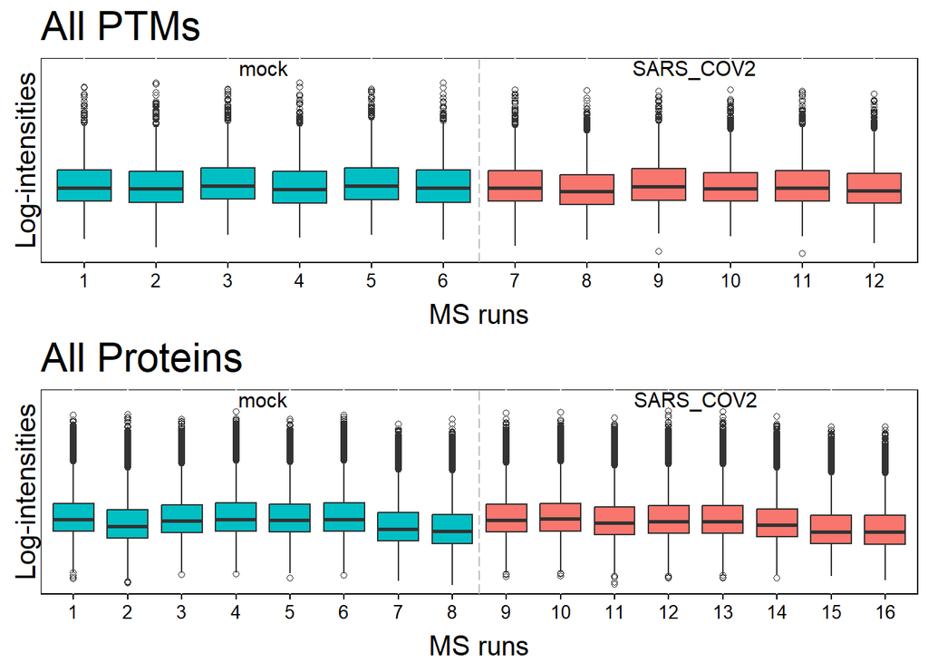

```
## Drew the Quality Contol plot(boxplot) for all ptms/proteins.
```

```r
dataProcessPlotsPTM(
  sum.obj,
  type = "QCPLOT",
  which.PTM = "allonly",
  address = FALSE
)
```

## 8.2. Profile plot d’une protéine

L’objectif du **Profile plot** est de visualiser la quantification d’une **protéine globale** à travers les runs (et donc les conditions), afin de :

- vérifier la **cohérence des réplicats biologiques** (les points doivent être proches au sein d’une condition),
- repérer d’éventuels **runs atypiques** (outliers),
- observer si la protéine semble varier entre conditions (ce qui pourra ensuite impacter l’interprétation des PTMs).

```r
library(data.table)

# 1) Les profile plots s'appuient sur FeatureLevelData (peptides/features).
prot_feat <- as.data.table(sum.obj$PROTEIN$FeatureLevelData)

# 2) Choisir une protéine qui a suffisamment de points mesurés pour faire un plot lisible
#    (newABUNDANCE est la valeur log2 après traitement/normalisation, avec imputation éventuelle)
one_prot <- prot_feat[!is.na(newABUNDANCE),
                      .N, by = PROTEIN][order(-N)][1, PROTEIN]

one_prot <- as.character(one_prot)
one_prot
```

```
## [1] "Q14204"
```

[figure not shown]

```
## Drew the Profile plot for Q14204 (1 of 1)
```

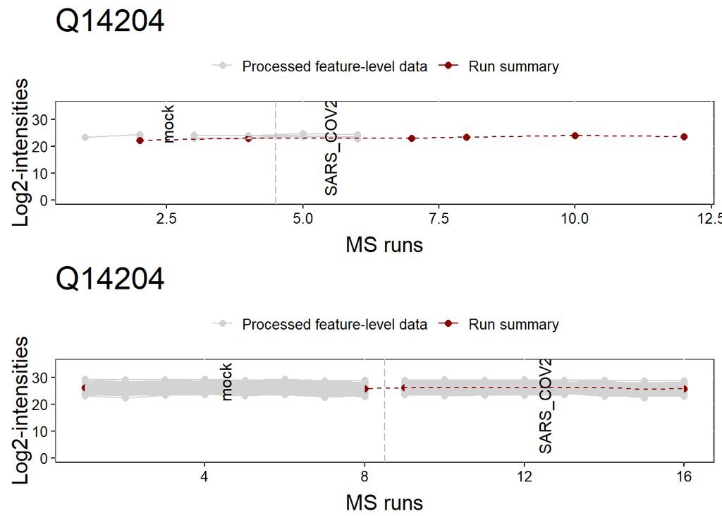

```
## Drew the Profile plot for  Q14204 ( 1  of  1 )
```

```r
# 3) Tracer le profile plot pour cette protéine
dataProcessPlotsPTM(
  sum.obj,
  type = "ProfilePlot",
  which.Protein = one_prot,
  address = FALSE
)
```

Interprétation rapide :

- Les **points gris** représentent les mesures au niveau peptides/features (variabilité technique/peptidique).
- La **courbe/points rouges** représentent la valeur résumée (abondance “protéine” par run).
- Si les valeurs rouges diffèrent fortement entre conditions, cela indique un **changement global de la protéine**, ce qui est précisément la raison pour laquelle MSstatsPTM calcule ensuite un modèle **ADJUSTED** (PTM ajustée par la protéine).

# 9. Analyse différentielle en utilisant `groupComparisonPTM`

Nous allons comparer SARS_COV2 à mock **séparément pour chaque point temporel**.  
Pour faire cela proprement, nous créons une étiquette de condition combinée, par exemple `mock_6h`, `SARS_COV2_6h`, etc.

## 9.1. Ajouter des étiquettes de groupe combinées dans l’annotation des données résumées

MSstatsPTM utilise les étiquettes présentes dans `ProteinLevelData`.

Nous allons modifier l’objet `sum.obj` :

```r
# On fait une copie pour conserver l'objet original
sum.obj2 <- sum.obj

# La colonne GROUP contient "mock" ou "SARS_COV2".
# On veut "mock_6h", "mock_24h", "SARS_COV2_6h", "SARS_COV2_24h".
#
# Le point de temps est encodé dans le nom de l'échantillon:
#   "_ME_" or "_TE_" = early time point (6h)
#   "_ML_" or "_TL_" = late time point (24h)
# On détecte ces patterns dans la colonne originalRUN en utilisant grepl().

for (part in c("PTM", "PROTEIN")) {
  dt <- as.data.table(sum.obj2[[part]]$ProteinLevelData)

  dt[, Time := fifelse(grepl("_(ME|TE)_", originalRUN), "6h",
                       fifelse(grepl("_(ML|TL)_", originalRUN), "24h", NA_character_))]

  dt[, GROUP := paste(GROUP, Time, sep = "_")]

  sum.obj2[[part]]$ProteinLevelData <- dt
}

unique(sum.obj2$PTM$ProteinLevelData[, .(GROUP, Time)])
```

```
##            GROUP   Time
##           <char> <char>
## 1:  SARS_COV2_6h     6h
## 2: SARS_COV2_24h    24h
## 3:       mock_6h     6h
## 4:      mock_24h    24h
```

```r
unique(sum.obj2$PROTEIN$ProteinLevelData[, .(GROUP, Time)])
```

```
##            GROUP   Time
##           <char> <char>
## 1:  SARS_COV2_6h     6h
## 2: SARS_COV2_24h    24h
## 3:       mock_6h     6h
## 4:      mock_24h    24h
```

```r
# On doit avoir:
# "mock_6h", "mock_24h", "SARS_COV2_6h", "SARS_COV2_24h"
```

## 9.2 Rappel sur les matrices de “design” et de “contraste”

Un modèle de régression linéaire peut s’écrire comme:
$$Y=XB+\epsilon$$
où $Y$ est un vecteur contenant les intensités des protéines/peptides dans différents échantillons, $B$ est un vecteur de paramètres, $\epsilon$ est un bruit blanc Gaussien, et $X$ est la matrice de **design**.

Cette dernière définit le modèle qui sera utilisé pour modéliser les intensités des protéines/peptides.

Par exemple, dans un cas simple “contrôle vs mutant” avec 3 réplicats dans chaque condition, le modèle linéaire sera:
$$\begin{bmatrix} y_{1}\\
y_{2}\\
y_{3}\\
y_{4}\\
y_{5}\\
y_{6}
\end{bmatrix}=\begin{bmatrix}1 & 0\\
1 & 0\\
1 & 0\\
1 & 1\\
1 & 1\\
1 & 1
\end{bmatrix}\begin{bmatrix}\alpha \\
\beta\end{bmatrix}+\epsilon$$

Lorqu’on utilise un test statistique, on s’intéresse à tester si des paramètres de ce modèle sont nuls (ou une combinaison linéaire de ces paramètres).

Par exemple, dans le cas “contrôle vs mutant” précédent, on s’intéresse à tester la nullité du paramètre $\beta$.

Ceci peut être formulé comme une multiplication entre une matrice de “contraste” et le vecteur de paramètres, c.-à-d. qu’on veut tester si:
$$\begin{bmatrix}0 & 1
\end{bmatrix}\begin{bmatrix}\alpha \\ \beta\end{bmatrix}=0
\Leftrightarrow \beta=0$$

Plus généralement, le test statistique peut s’exprimer comme:
$$H_0: C^tB=0\qquad vs\qquad H_1:
C^tB\neq0$$
où $C$ est définie comme la matrice de **contraste**.

## 9.3. Définir une matrice de contrastes (groupes spécifiques au temps)

À ce stade, nous avons modifié `sum.obj2` de sorte que la colonne GROUP contienne quatre niveaux :

- `mock_6h`
- `mock_24h`
- `SARS_COV2_6h`
- `SARS_COV2_24h`

On peut maintenant créer des “contrastes” à tester :

- `SARS_COV2_6h - mock_6h`
- `SARS_COV2_24h - mock_24h`

```r
# List the groups available in the PROTEIN summarized table
groups <- sort(unique(sum.obj2$PROTEIN$ProteinLevelData$GROUP))
groups
```

```
## [1] "mock_24h"      "mock_6h"       "SARS_COV2_24h" "SARS_COV2_6h"
```

```r
# On créé une matrice de contraste de deux lignes:
# 1) SARS_COV2_6h - mock_6h
# 2) SARS_COV2_24h - mock_24h
comparison <- matrix(0, nrow = 2, ncol = length(groups))
colnames(comparison) <- groups
rownames(comparison) <- c("SARS6h-mock6h", "SARS24h-mock24h")

comparison["SARS6h-mock6h",  "mock_6h"]      <- -1
comparison["SARS6h-mock6h",  "SARS_COV2_6h"] <-  1

comparison["SARS24h-mock24h", "mock_24h"]       <- -1
comparison["SARS24h-mock24h", "SARS_COV2_24h"]  <-  1

#Affichage pour vérifier que c'est correct
comparison
```

```
##                 mock_24h mock_6h SARS_COV2_24h SARS_COV2_6h
## SARS6h-mock6h          0      -1             0            1
## SARS24h-mock24h       -1       0             1            0
```

## 9.4. Run `groupComparisonPTM`

Cette étape statistique est le point essentiel. Elle estime trois modèles :

- un modèle PTM sur les données de phosphorylation résumées,
- un modèle protéine sur les données de protéomique globale résumées,
- puis calcule les effets PTM ajustés par l’abondance de la protéine.

```r
model.obj <- groupComparisonPTM(
  sum.obj2,
  data.type="LabelFree",
  contrast.matrix = comparison,
  use_log_file = FALSE,
  append = FALSE,
  verbose = FALSE
)
```

```
## Starting PTM modeling...
```

```
## Starting Protein modeling...
```

```
## Starting adjustment...
```

```r
head(model.obj$PTM.Model) #Modèle PTM "non ajusté"
head(model.obj$PROTEIN.Model) #Modèle protéines
head(model.obj$ADJUSTED.Model) # Modèle PTM ajusté par rapport aux protéines
```

[output not shown]

Après `groupComparisonPTM()`, MSstatsPTM retourne trois datasets:

- `model.obj$PTM.Model` (unadjusted PTM changes)
- `model.obj$PROTEIN.Model` (global protein changes)
- `model.obj$ADJUSTED.Model` (effets PTM ajustés par l’abondance de la protéine)

Une question très fréquente est :

> “Ce site de phosphorylation est significatif dans PTM.Model. Est-il toujours significatif après prise en compte des variations au niveau de la protéine ?”

Ci-dessous, un petit bloc d’aide permet de sélectionner un site PTM et de comparer directement :

- le log2FC PTM (non ajusté) vs le log2FC ajusté
- les p-values correspondantes / p-values ajustées
- ce que fait la protéine (variation globale)

### 9.4.1. Choisir un site PTM d’intérêt

Ici, nous sélectionnons le site le plus significatif après ajustement (p-value ajustée minimale) dans le premier contraste.

```r
# Contrastes disponibles
unique(model.obj$ADJUSTED.Model$Label)
```

```
## [1] "SARS6h-mock6h"   "SARS24h-mock24h"
```

```r
# On choisi un contraste
contrast_to_show <- unique(model.obj$ADJUSTED.Model$Label)[1]
contrast_to_show
```

```
## [1] "SARS6h-mock6h"
```

```r
adj_res <- as.data.table(model.obj$ADJUSTED.Model)[Label == contrast_to_show]

# PTM le plus significatif après ajustement (plus petite adj.pvalue)
site_to_show <- adj_res[order(adj.pvalue)][1, Protein]
site_to_show
```

```
## [1] Q96D46_S468_T470
## 2831 Levels: A1X283_S291 A6NKD9_S178 A6NKD9_S246 C9JLW8_S17_S21 ... Q9Y6X2_S454_S455_S456
```

Remarque : dans les résultats de MSstatsPTM, l’identifiant du PTM est stocké dans la colonne `Protein` des tables PTM/ADJUSTED.

### 9.4.2. PTM.Model vs ADJUSTED.Model vs PROTEIN.Model pour ce site

On cherche à savoir si le changement d’abondance du PTM est dû au changement d’abondance de la protéine ou s’il y a un changement qui est dû à la modification

```r
ptm_res <- as.data.table(model.obj$PTM.Model)[Label == contrast_to_show & Protein == site_to_show]
adj_res_one <- as.data.table(model.obj$ADJUSTED.Model)[Label == contrast_to_show & Protein == site_to_show]

# Le numéro d'accession de la protéine est inclu dans l'ID du PTM (ex: "P12345_S67")
# On utilise la fonction sub() pour extraire cet ID
base_protein <- sub("(_.*)$", "", site_to_show)
base_protein
```

```
## [1] "Q96D46"
```

```r
prot_res <- as.data.table(model.obj$PROTEIN.Model)[Label == contrast_to_show & Protein == base_protein]

list(
  PTM = ptm_res,
  ADJUSTED = adj_res_one,
  PROTEIN = prot_res
)
```

```
## $PTM
##             Protein         Label  log2FC        SE   Tvalue    DF       pvalue
##              <fctr>        <char>   <num>     <num>    <num> <int>        <num>
## 1: Q96D46_S468_T470 SARS6h-mock6h 1.52183 0.1405596 10.82694     6 3.675578e-05
##    adj.pvalue  issue MissingPercentage ImputationPercentage
##         <num> <char>             <num>                <num>
## 1: 0.03293318   <NA>         0.5416667           0.04166667
##
## $ADJUSTED
##             Protein         Label   log2FC        SE   Tvalue       DF
##              <fctr>        <char>    <num>     <num>    <num>    <num>
## 1: Q96D46_S468_T470 SARS6h-mock6h 1.494432 0.1960683 7.621997 14.23034
##          pvalue  adj.pvalue GlobalProtein Adjusted
##           <num>       <num>        <char>   <lgcl>
## 1: 2.163197e-06 0.001694409        Q96D46     TRUE
##
## $PROTEIN
##    Protein         Label     log2FC        SE    Tvalue    DF    pvalue
##     <fctr>        <char>      <num>     <num>     <num> <int>     <num>
## 1:  Q96D46 SARS6h-mock6h 0.02739869 0.1366959 0.2004353     9 0.8455962
##    adj.pvalue  issue MissingPercentage ImputationPercentage
##         <num> <char>             <num>                <num>
## 1:   0.969159   <NA>         0.6796875            0.1796875
```

### 9.4.3. Table d’interprétation “compacte”

Cette table contient les valeurs clés:

- log2FC PTM (non ajusté)
- log2FC de la protéine
- log2FC ajusté (= PTM - protéine)
- p-values ajustées

```r
interp <- data.table(
  Contrast = contrast_to_show,
  PTM_site = site_to_show,
  Protein  = base_protein,
  PTM_log2FC = ptm_res$log2FC,
  Protein_log2FC = prot_res$log2FC,
  Adjusted_log2FC = adj_res_one$log2FC,
  PTM_adj_pvalue = ptm_res$adj.pvalue,
  Adjusted_adj_pvalue = adj_res_one$adj.pvalue
)

interp
```

```
##         Contrast         PTM_site Protein PTM_log2FC Protein_log2FC
##           <char>           <fctr>  <char>      <num>          <num>
## 1: SARS6h-mock6h Q96D46_S468_T470  Q96D46    1.52183     0.02739869
##    Adjusted_log2FC PTM_adj_pvalue Adjusted_adj_pvalue
##              <num>          <num>               <num>
## 1:        1.494432     0.03293318         0.001694409
```

### 9.4.4. Comment expliquer le résultat

Utilisez cette logique :

- Si le **log2FC PTM est élevé**, mais que le **log2FC de la protéine est aussi élevé dans la même direction**, alors la variation observée du PTM peut simplement refléter une variation d’abondance de la protéine.
- Si le **log2FC ajusté reste élevé et significatif**, alors le PTM varie **au-delà** de l’abondance de la protéine (ce qui est plus interprétable biologiquement comme une régulation au niveau de la modification).
- Si le **log2FC ajusté se rapproche de 0** (et/ou perd sa significativité), alors le signal PTM initial était probablement confondu avec les changements d’abondance de la protéine.

Optionnel : afficher plusieurs sites à la fois (top 10 après ajustement)  
C’est utile pour montrer que l’ajustement peut modifier l’ordre des « meilleurs hits » (top hits).

```r
top10 <- adj_res[order(adj.pvalue)][1:10, .(Protein, log2FC, adj.pvalue)]
top10
```

```
##                Protein     log2FC  adj.pvalue
##                 <fctr>      <num>       <num>
##  1:   Q96D46_S468_T470  1.4944318 0.001694409
##  2:   Q9Y6G9_S510_T513  0.7666222 0.001694409
##  3:        O14654_S465 -0.4430272 0.005867941
##  4:        Q86UE4_S298  0.9423134 0.005867941
##  5:        Q9BWH2_S151  1.3746176 0.005867941
##  6: P11717_S2400_S2409  0.8802661 0.008672453
##  7:        Q8IVT2_S541  1.0549328 0.008672453
##  8:         P04792_S82  0.7106782 0.009197062
##  9:       P46821_S1852  0.8989056 0.009337473
## 10:             P62906 -1.2920697 0.009337473
```

# 10. Visualisation des résultats (Volcano + Heatmap)

## 10.1. Volcano plots

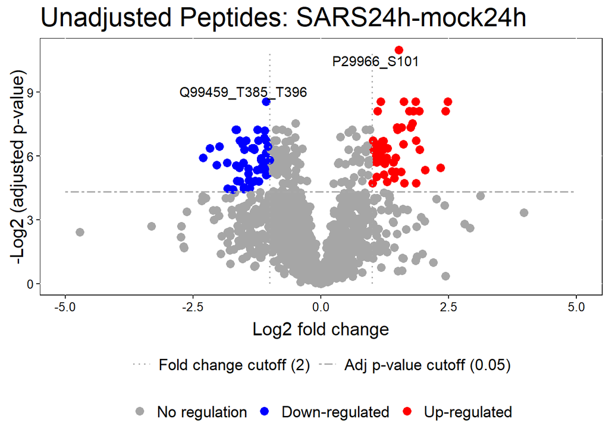

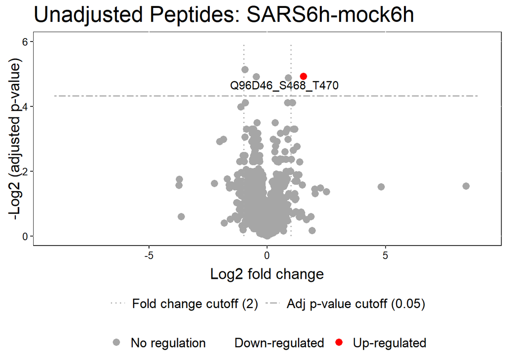

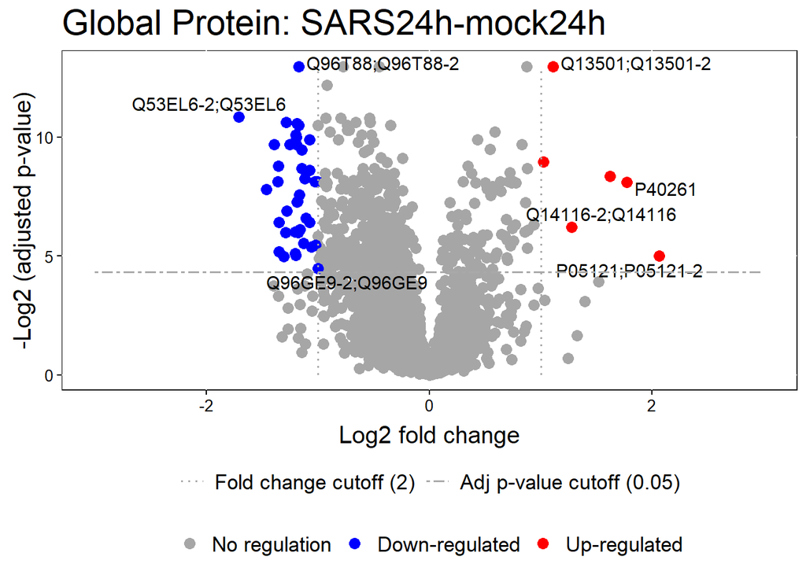

```
## The volcano plot for SARS6h-mock6h does not show the protein names because none of them are significant.
```

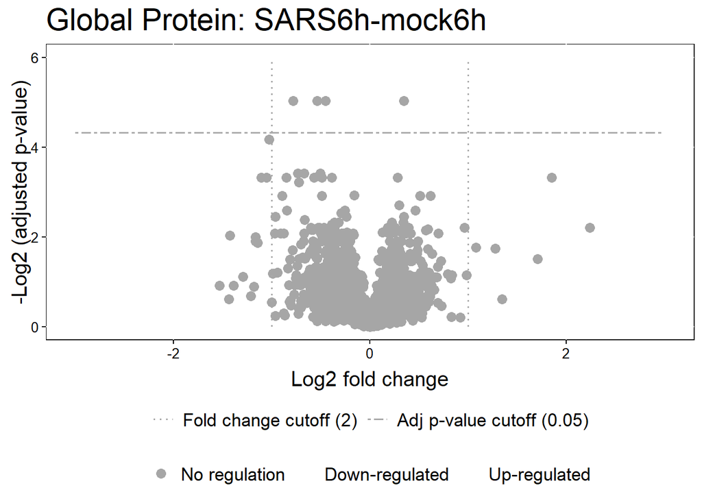

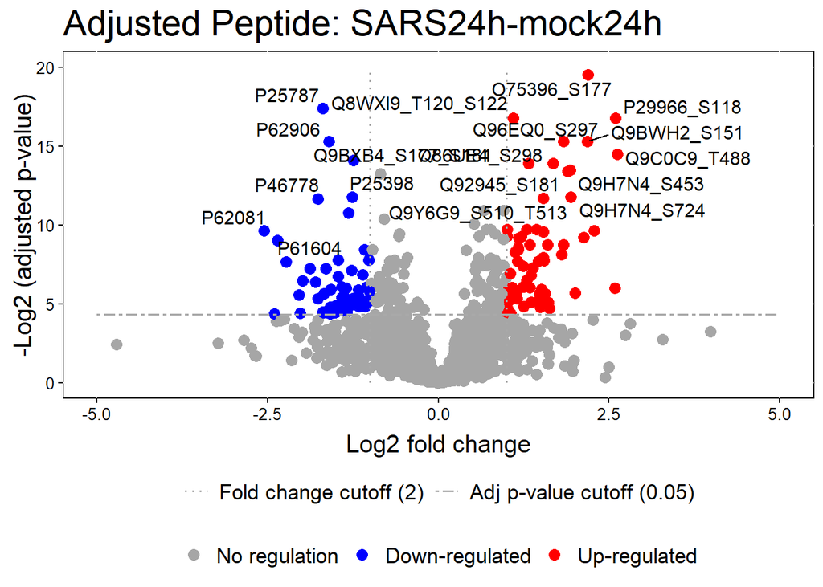

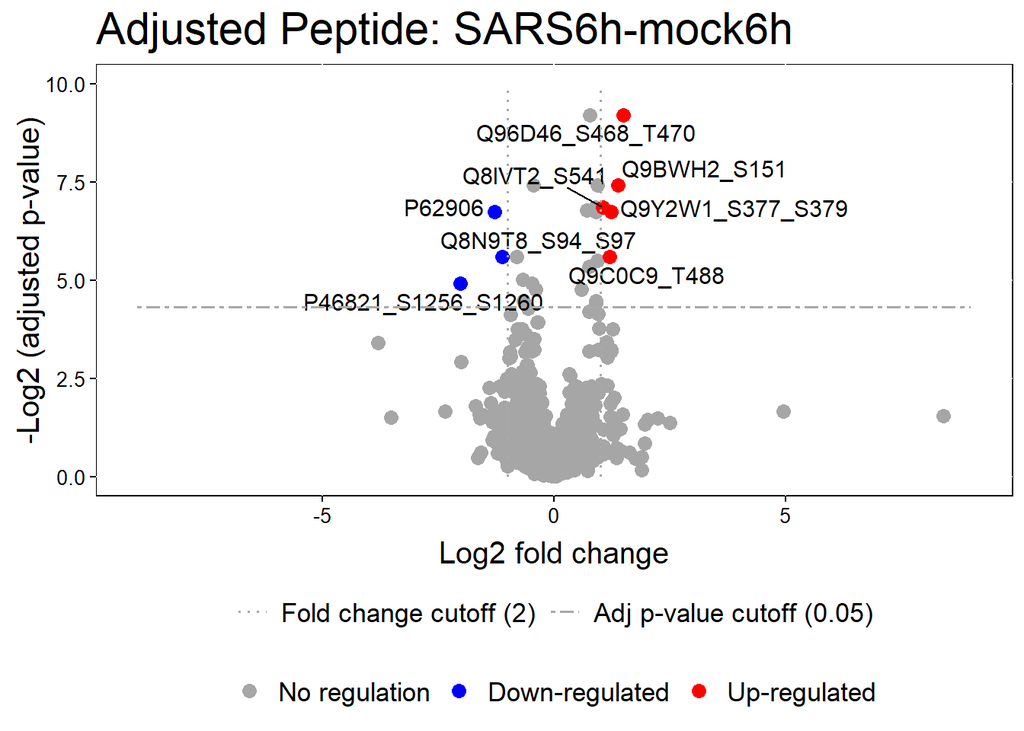

```r
groupComparisonPlotsPTM(
  data = model.obj,
  type = "VolcanoPlot",
  FCcutoff = 2,
  logBase.pvalue = 2,
  address = FALSE
)
```

## 10.2. Heatmap

Affiche les 30 premières PTMs:

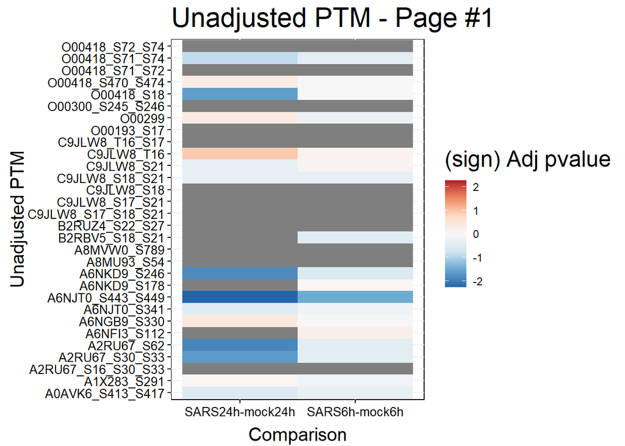

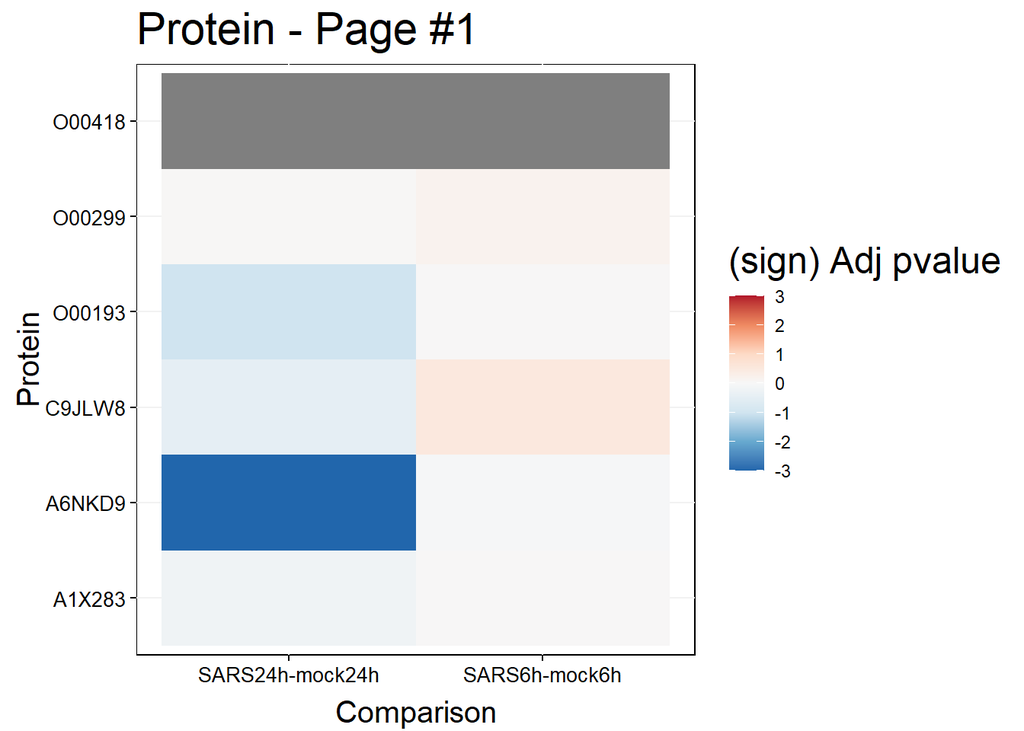

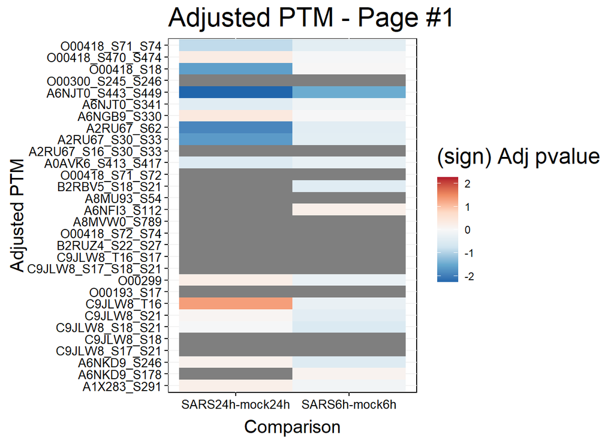

```r
groupComparisonPlotsPTM(
  data = model.obj,
  type = "Heatmap",
  which.PTM = 1:30,
  address = FALSE
)
```

# 11. Calcul du nombre d’échantillons nécessaires

Cette étape utilise la variabilité observée dans l’expérience actuelle pour estimer combien de réplicats biologiques seront nécessaires dans une future expérience afin de détecter des changements d’une amplitude donnée avec un FDR et une puissance statistique souhaités. Idéalement, cette étude est à effectuer sur des données “test”.

```r
ss <- designSampleSizePTM(
  model.obj,
  desiredFC = c(1.0, 1.5, 2.0),  # log2 fold changes of interest
  FDR = 0.05,
  numSample = TRUE,
  power = 0.8
)

head(ss)
```

```
##   desiredFC numSample  FDR power
## 1     1.000       Inf 0.05   0.8
## 2     1.025      3235 0.05   0.8
## 3     1.050       829 0.05   0.8
## 4     1.075       377 0.05   0.8
## 5     1.100       217 0.05   0.8
## 6     1.125       142 0.05   0.8
```

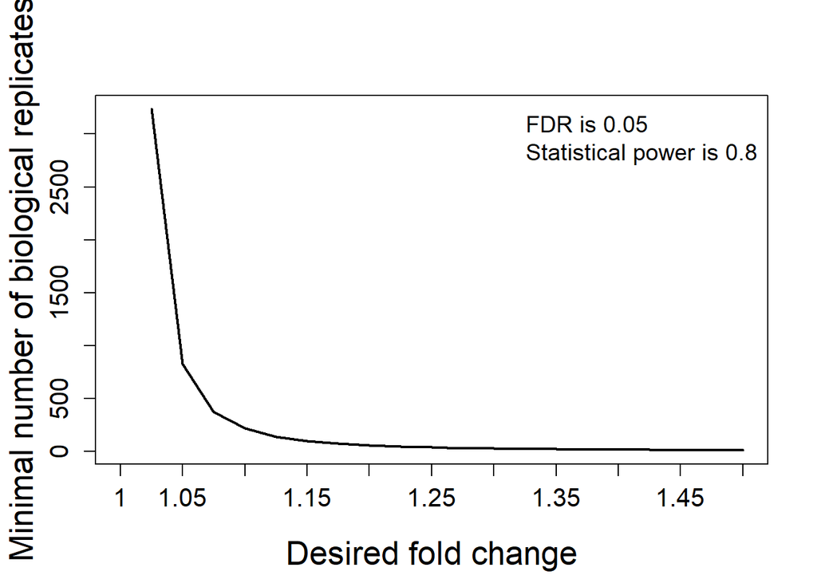

```r
MSstats::designSampleSizePlots(ss)
```

# 12. Références

- Kohler et al. *MSstatsPTM: Statistical Relative Quantification of Posttranslational Modifications in Bottom-Up Mass Spectrometry-Based Proteomics.* Molecular and cellular proteomics, 2023.
- Kohler et al. *MSstats Version 4.0: Statistical Analyses of Quantitative Mass Spectrometry-Based Proteomic Experiments with Chromatography-Based Quantification at Scale.* Journal of proteome research, 2023.